# Decision tree building, Pruning 1

lec7

hanbyeol true  
04-16-2021

# 어떤 x를 기준으로 나눠야 하는가?(평균 하나로 할 때)

```r
library(magrittr)

x <- -10:10
y <- x^2
```

which(x < s) : x가 s보다 작은 것들의 위치는 어디니? x[group1_index] : 실제로 x가 s보다 작은 것들이 뭔지를 보여줌

예측값으로 사용할 것은 group별로 y값들의 평균임!

```r
s <- -2
group1_index <- which(x < s)
group2_index <- which(x >= s)

x[group1_index]
```

```
[1] -10  -9  -8  -7  -6  -5  -4  -3
```

```r
x[group2_index]
```

```
 [1] -2 -1  0  1  2  3  4  5  6  7  8  9 10
```

```r
pred_group1 <- mean(y[group1_index])
pred_group2 <- mean(y[group2_index])

#rss들의 합
result <- sum((y[group1_index] - pred_group1)^2)+
    sum((y[group2_index] - pred_group2)^2)
```

이제 저 것들을 s, x, y의 함수로 만들 것임

```r
rss <- function(s, x, y){
    group1_index <- which(x < s)
    group2_index <- which(x >= s)

    x[group1_index]
    x[group2_index]

    pred_group1 <- mean(y[group1_index])
    pred_group2 <- mean(y[group2_index])

    result <- sum((y[group1_index] - pred_group1)^2)+
    sum((y[group2_index] - pred_group2)^2)
    result
}
```

s의 후보군들(?) 정하고 그런 s들로 rss를 구하고자 한다.

```r
# x랑 y를 고정시키고 s만 바뀐다고 생각

rss <- function(s){
    x <- -10:10
    y <- x^2

    group1_index <- which(x < s)
    group2_index <- which(x >= s)

    x[group1_index]
    x[group2_index]

    pred_group1 <- mean(y[group1_index])
    pred_group2 <- mean(y[group2_index])

    result <- sum((y[group1_index] - pred_group1)^2)+
    sum((y[group2_index] - pred_group2)^2)
    result
}
rss(-2)
```

```
[1] 20916
```

```r
s <- seq(-10, 10, by = 0.01)
rss_result <- sapply(s,rss)
```

sapply(x,y) : x의 모든 원소들을 rss라는 함수에 입력값으로 넣어라

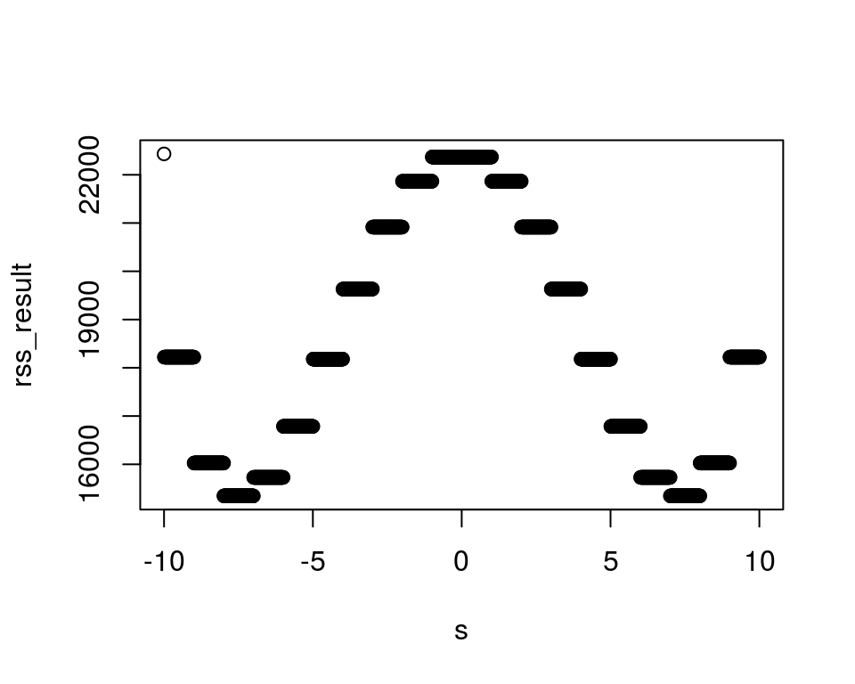

```r
plot(s, rss_result)
```

```r
which.min(rss_result)
```

```
[1] 202
```

```r
s[which.min(rss_result)]
```

```
[1] -7.99
```

rss_result를 그려라 which.min(rss_result): rss_result의 몇번째 값이 가장 작은 값인지 확인해보기 s[which.min(rss_result)] : 그때의 s값은 뭐니?

그럼 그 s값을 기준으로 그룹이 나뉘니까 어떤 값이 예측값으로 사용될 것인지 알 수 있다.

```r
group1_index <- which(x < -7.99)
group2_index <- which(x >= -7.99)

mean(y[group1_index])
```

```
[1] 81.66667
```

```r
mean(y[group2_index])
```

```
[1] 29.16667
```

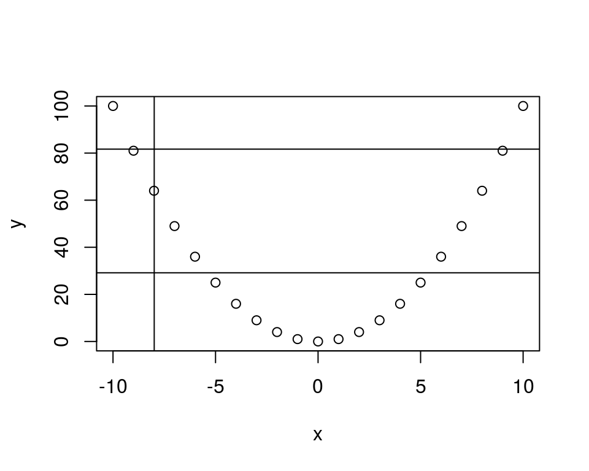

```r
plot(x,y)
abline(h=mean(y[group1_index]))
abline(h=mean(y[group2_index]))
abline(v=-7.99)
```

왼쪽 그룹은 81.667로 예측을하고 오른쪽 그룹은 29.16667로 예측한다는 것을 알 수 있다.

# overfitting을 방지하기 위해서는 어째야함?

linear regression에서는 ridge, lasso에 penalty를 부과하는 방법을 사용했음 그럼 tree에서는? -> *prunning*

# R에서 tree하는 방법

```r
library(ISLR)
library(tidyverse)
library(MASS)
library(rpart)
library(rpart.plot) #tree 시각화 하는 패키지
```

```r
attach(Boston)

Boston %>% dim()
```

```
[1] 506  14
```

```r
Boston %>% head()
```

```
     crim zn indus chas   nox    rm  age    dis rad tax ptratio
1 0.00632 18  2.31    0 0.538 6.575 65.2 4.0900   1 296    15.3
2 0.02731  0  7.07    0 0.469 6.421 78.9 4.9671   2 242    17.8
3 0.02729  0  7.07    0 0.469 7.185 61.1 4.9671   2 242    17.8
4 0.03237  0  2.18    0 0.458 6.998 45.8 6.0622   3 222    18.7
5 0.06905  0  2.18    0 0.458 7.147 54.2 6.0622   3 222    18.7
6 0.02985  0  2.18    0 0.458 6.430 58.7 6.0622   3 222    18.7
   black lstat medv
1 396.90  4.98 24.0
2 396.90  9.14 21.6
3 392.83  4.03 34.7
4 394.63  2.94 33.4
5 396.90  5.33 36.2
6 394.12  5.21 28.7
```

## decision tree building, Purnning 방법

regression 할때는 lm()에 넣었는데 decision tree에서는 rpart() 함수에 넣음

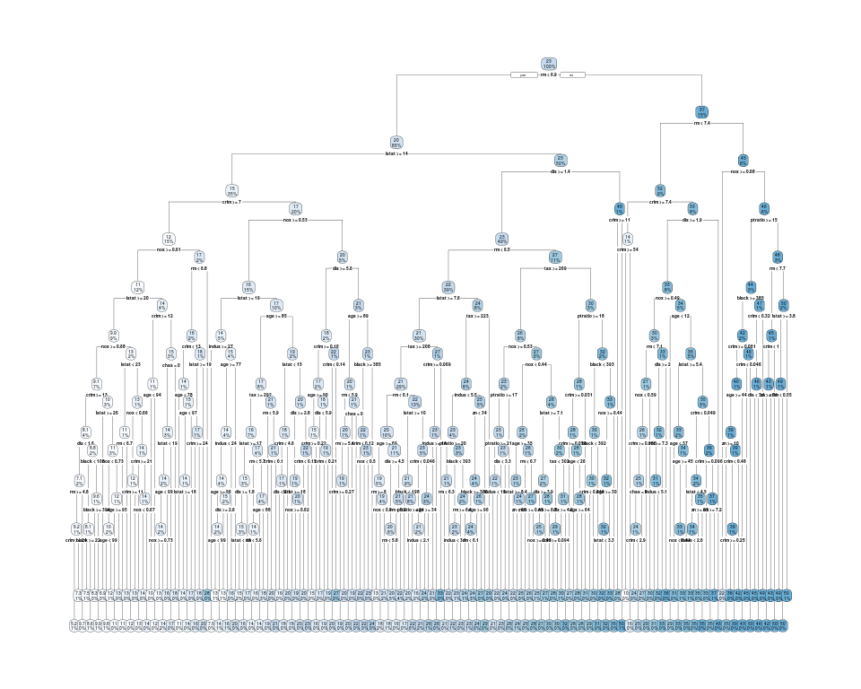

```r
boston_tree <- rpart(medv ~ .,
                     data = Boston,
                     method = "anova", #rpart에서는 anova로 regression을 적용
                     control = rpart.control(
                       cp = 0, #anova split일 때: 나눌 때마다 R^2가 증가할텐데, 증가하는 정도를 어느정도로 할것인지
                       #cp가 높을수록 tree구조가 단순해진다
                       minbucket = 1, #terminal node가 1개 일 때까지 building
                       maxdepth = 10))
rpart.plot(boston_tree)
```

rpart.control 함수에 자동으로 xval하는 것이 저장되어있음(validation 진행)

```r
class(boston_tree$cptable)
```

```
[1] "matrix" "array"
```

matrix니까

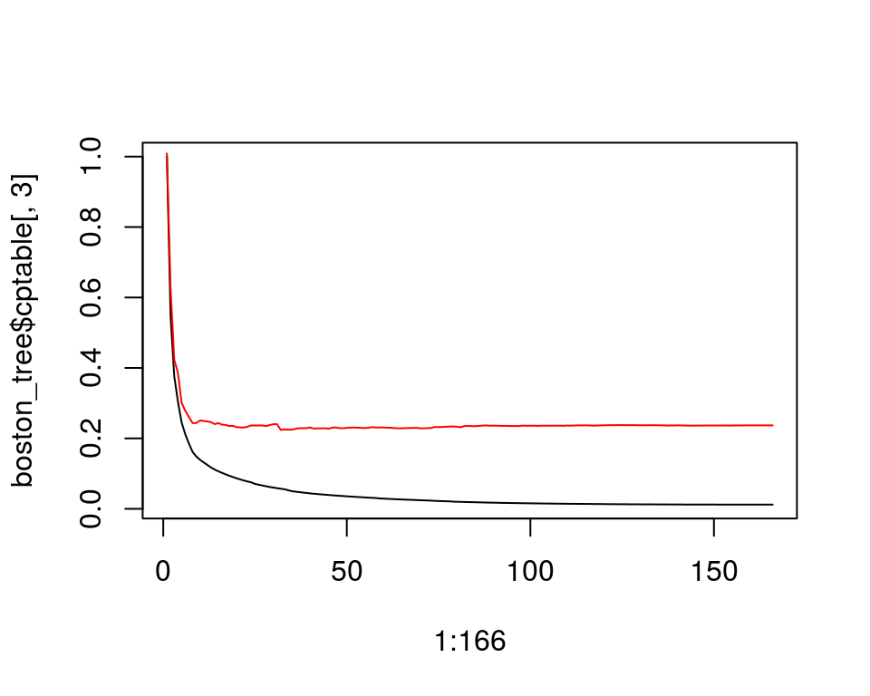

```r
plot(1:166, boston_tree$cptable[,3], type = "l") #cp에 따라서 rel error가 어떻게 바뀌는지(train set에 대한 error값-쭉 떨어짐)
points(1:166, boston_tree$cptable[,4],type = "l", col="red") #cp에 따라서 cross val가 어떻게 바뀌는지(cross validation에 대한 error값-가장 낮은 시점부터 overfitting이 시작됨)
```

### cp값에 따라서 prune을 할 수 있다

```r
printcp(boston_tree)
```

```
Regression tree:
rpart(formula = medv ~ ., data = Boston, method = "anova", control = rpart.control(cp = 0,
    minbucket = 1, maxdepth = 10))

Variables actually used in tree construction:
 [1] age     black   chas    crim    dis     indus   lstat   nox
 [9] ptratio rm      tax     zn

Root node error: 42716/506 = 84.42

n= 506

            CP nsplit rel error  xerror     xstd
1   4.5274e-01      0  1.000000 1.00874 0.083360
2   1.7117e-01      1  0.547256 0.62423 0.057656
```

[output cut: 164 more lines]

spli할수록 rel error가 작아짐(train data에 대해서 학습을 더 잘한다고 볼 수 있음) xerror: cross validation error: train data로 학습할 때 xerror가 감소하다가 overfit되는 지점부터는 다시 증가함

우리의 목적: cp중에서 cross validarion이 작고, overfit되지 않은 값을 찾기를 원함

cp중에서 cross validarion이 작은 것이 어디있니: which.min():index를 찾아내고 그때의 cp값을 잡아옴

```r
bestcp <- boston_tree$cptable[which.min(boston_tree$cptable[,"xerror"]),"CP"]
```

위에서 정한 cp를 기준으로 prune을 해라.

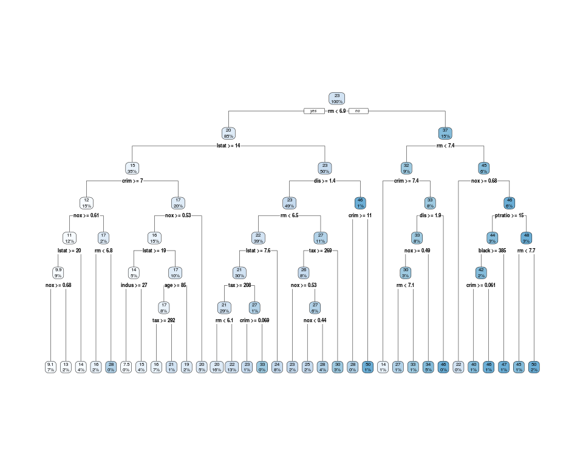

```r
best_boston_tree <- prune(boston_tree, cp = bestcp)
rpart.plot(best_boston_tree)
```

복잡한 tree에서 prune을 하는 이유: optimal tree를 찾는 것이 목적인데, Gini index와 Entropy를 기준으로 설정하는 것보다 cp를 이용해서 prunning을 하는 방법이 좋은 tree를 찾는다고 알려져있음(in textbook) +남들에게 설명해주기 편함(현상해석을 분석할 때 어덯게 왜 작동하는지) -> predict 모델에서는 이유를 설명하기 보다는 잘 추정하는 것이 더 중요함